# Summary statistics from ClonalOrigin seq and pair models

```python
import numpy as np
import matplotlib.pyplot as plt
from Bio import Phylo
import torch
import sys
sys.path.append('../pysimARG')
from clonal_genealogy import ClonalTree
from newick_to_tree import newick_to_tree

torch_device = "cpu"
```

## Load simulation data

Load genome data and clonal tree.

```python
genome_simbac = np.loadtxt("../data/SimBac/genomes_bool.csv", delimiter=",", dtype=bool)
```

```python
genome_simbac.shape
```

```
(10, 100000)
```

```python
np.random.seed(100)
clonal_tree = ClonalTree(n=10)

# Load phylo tree and convert to ClonalTree format
phylo_tree = Phylo.read("../data/SimBac/clonal_frame.nwk", "newick")
Phylo.draw_ascii(phylo_tree)

edge, node_height = newick_to_tree(phylo_tree)
clonal_tree.edge = edge
clonal_tree.node_height = node_height
clonal_tree.height = np.max(node_height)
clonal_tree.length = np.sum(edge[:, 2])
```

```
                                                                   _______ 2
                                        __________________________|
                            ___________|                          |_______ 8
                           |           |
                           |           |___________________________________ 1
                        ___|                         _____________________ 6
                       |   |                       ,|
                       |   |                       ||  ___________________ 3
                       |   |                       ||_|
                       |   |_______________________|  |___________________ 9
  _____________________|                           |
 |                     |                           |         _____________ 5
 |                     |                           |________|
_|                     |                                    |_____________ 7
 |                     |
 |                     |__________________________________________________ 4
 |________________________________________________________________________ 0
```

```python
np.sum(clonal_tree.edge[:, 2]) * 0.1 / 2
```

```
np.float64(0.19363880500000005)
```

## Summary statistics

This notebook evaluates the proportions and exact values of LD and G4 for comparison and selection. The items used in the summary statistics is listed below. Let $d$ denote the distance between sites in a pair, and $L$ denote the length of the gene segment.

1. $\text{LD}_{d < L/2}$
2. $\text{LD}_{d \geq L/2}$
3. $\# \text{G4}_{d < L/2}$
4. $\# \text{G4}_{d \geq L/2}$
5. $\frac{\text{LD}_{d < L/2}}{\# \text{segregating pairs that } d < L/2}$
6. $\frac{\text{LD}_{d \geq L/2}}{\# \text{segregating pairs that } d \geq L/2}$
7. $\frac{\# \text{G4}_{d < L/2}}{\# \text{segregating pairs that } d < L/2}$
8. $\frac{\# \text{G4}_{d \geq L/2}}{\# \text{segregating pairs that } d \geq L/2}$
9. $\text{LD}_{20 \leq d < 50}$
10. $\text{LD}_{50 \leq d \leq 80}$
11. $\# \text{G4}_{20 \leq d < 50}$
12. $\# \text{G4}_{50 \leq d \leq 80}$
13. $\frac{\text{LD}_{20 \leq d < 50}}{\# \text{segregating pairs that } 20 \leq d < 50}$
14. $\frac{\text{LD}_{50 \leq d \leq 80}}{\# \text{segregating pairs that } 50 \leq d \leq 80}$
15. $\frac{\# \text{G4}_{20 \leq d < 50}}{\# \text{segregating pairs that } 20 \leq d < 50}$
16. $\frac{\# \text{G4}_{50 \leq d \leq 80}}{\# \text{segregating pairs that } 50 \leq d \leq 80}$
17. homoplasy index based on the clonal structure
18. Proportion of segregating sites
19. $L$

### Get summary statistics from SimBac data

```python
x_500_mat = np.loadtxt("../data/x_500_mat.csv", delimiter=",")
x_2000_mat = np.loadtxt("../data/x_2000_mat.csv", delimiter=",")
x_6000_mat = np.loadtxt("../data/x_6000_mat.csv", delimiter=",")

x_o_500 = torch.tensor(x_500_mat[0, :], device=torch_device)
x_o_500 = x_o_500.to(torch.float32)

x_o_2000 = torch.tensor(x_2000_mat[0, :], device=torch_device)
x_o_2000 = x_o_2000.to(torch.float32)

x_o_6000 = torch.tensor(x_6000_mat[0, :], device=torch_device)
x_o_6000 = x_o_6000.to(torch.float32)
```

### Summary statistics from ClonalOrigin seq model

In this section, we plot the summary statistics changing by one model parameter each time. When unchanged, the parameters were $\rho_s = 0.02$, $\theta_s = 0.05$, and $L = 2000$.

```python
x_seq = np.loadtxt('../data/x_seq.csv', delimiter=",")
rho_seq = np.loadtxt('../data/rho_site_seq.csv', delimiter=",")
theta_seq = np.loadtxt('../data/theta_site_seq.csv', delimiter=",")
L_seq = np.loadtxt('../data/L_seq.csv', delimiter=",")
x_seq.shape, rho_seq.shape, theta_seq.shape, L_seq.shape
```

```
((200, 4), (200, 19), (200, 19), (200, 19))
```

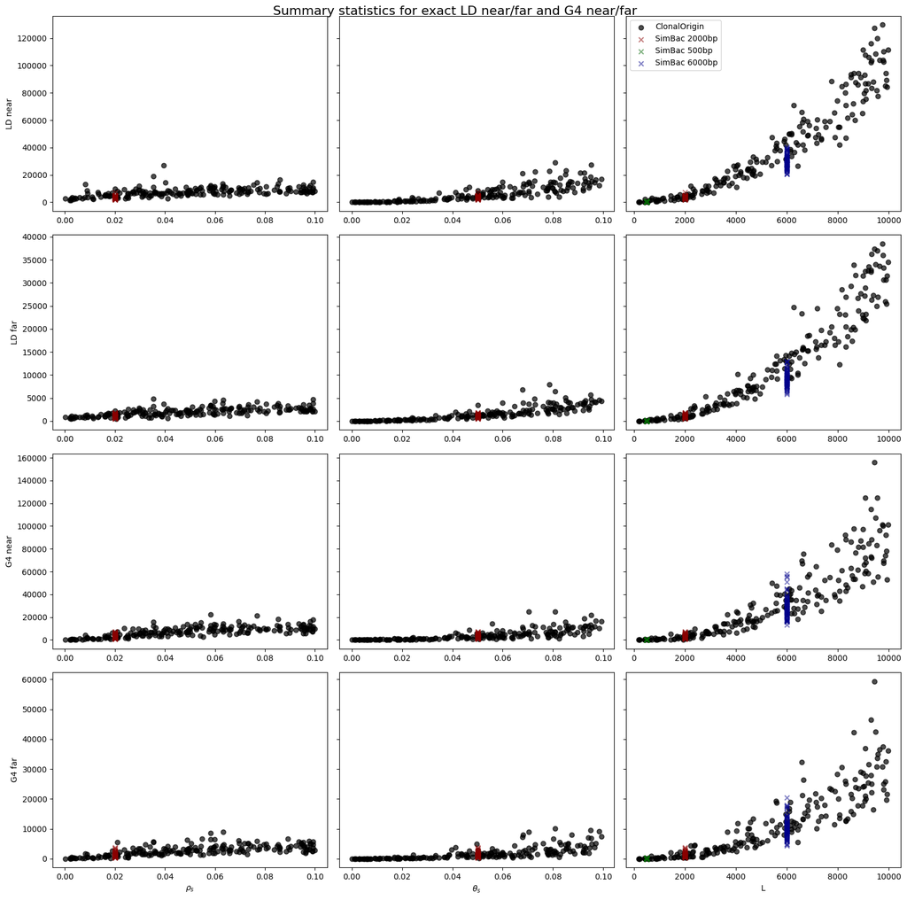

```python
fig, axs = plt.subplots(4, 3, figsize=(16, 16), sharey='row')

x_data = [x_seq[:, 0], x_seq[:, 2], x_seq[:, 3]]
true_x = [0.02, 0.05, 2000]
y_data_matrices = [rho_seq, theta_seq, L_seq]
x_labels = [r'$\rho_s$', r'$\theta_s$', "L"]

for col in range(3):
    x_var = x_data[col]
    fix_x = true_x[col]
    y_mat = y_data_matrices[col]

    axs[0, col].scatter(x_var, y_mat[:, 0], marker='o', color='black', label="ClonalOrigin", alpha=0.7)
    axs[0, col].scatter(np.full(100, fix_x), x_2000_mat[:, 0], marker='x', color='darkred', label = "SimBac 2000bp", alpha=0.5)

    axs[1, col].scatter(x_var, y_mat[:, 1], marker='o', color='black', alpha=0.7)
    axs[1, col].scatter(np.full(100, fix_x), x_2000_mat[:, 1], marker='x', color='darkred', label = "SimBac 2000bp", alpha=0.5)

    axs[2, col].scatter(x_var, y_mat[:, 2], marker='o', color='black', alpha=0.7)
    axs[2, col].scatter(np.full(100, fix_x), x_2000_mat[:, 2], marker='x', color='darkred', label = "SimBac 2000bp", alpha=0.5)

    axs[3, col].scatter(x_var, y_mat[:, 3], marker='o', color='black', alpha=0.7)
    axs[3, col].scatter(np.full(100, fix_x), x_2000_mat[:, 3], marker='x', color='darkred', label = "SimBac 2000bp", alpha=0.5)
    axs[3, col].set_xlabel(x_labels[col])

    if col == 2:
        axs[0, col].scatter(np.full(100, 500), x_500_mat[:, 0], marker='x', color='darkgreen', label = "SimBac 500bp", alpha=0.5)
        axs[0, col].scatter(np.full(100, 6000), x_6000_mat[:, 0], marker='x', color='darkblue', label = "SimBac 6000bp", alpha=0.5)

        axs[1, col].scatter(np.full(100, 500), x_500_mat[:, 1], marker='x', color='darkgreen', label = "SimBac 500bp", alpha=0.5)
        axs[1, col].scatter(np.full(100, 6000), x_6000_mat[:, 1], marker='x', color='darkblue', label = "SimBac 6000bp", alpha=0.5)

        axs[2, col].scatter(np.full(100, 500), x_500_mat[:, 2], marker='x', color='darkgreen', label = "SimBac 500bp", alpha=0.5)
        axs[2, col].scatter(np.full(100, 6000), x_6000_mat[:, 2], marker='x', color='darkblue', label = "SimBac 6000bp", alpha=0.5)

        axs[3, col].scatter(np.full(100, 500), x_500_mat[:, 3], marker='x', color='darkgreen', label = "SimBac 500bp", alpha=0.5)
        axs[3, col].scatter(np.full(100, 6000), x_6000_mat[:, 3], marker='x', color='darkblue', label = "SimBac 6000bp", alpha=0.5)

axs[0, 0].set_ylabel('LD near')
axs[1, 0].set_ylabel('LD far')
axs[2, 0].set_ylabel('G4 near')
axs[3, 0].set_ylabel('G4 far')

axs[0, 2].legend(loc='best')

plt.suptitle('Summary statistics for exact LD near/far and G4 near/far', fontsize=16)
plt.tight_layout()
plt.show()
```

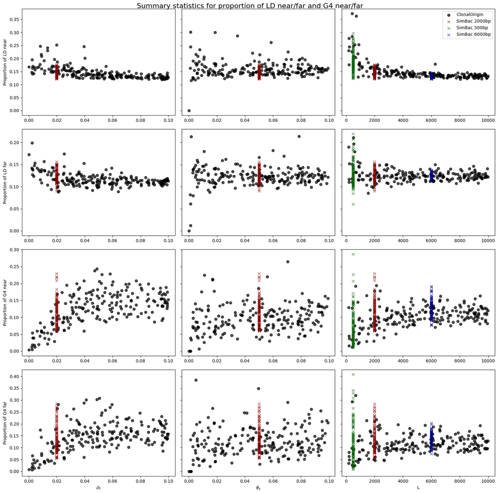

```python
fig, axs = plt.subplots(4, 3, figsize=(16, 16), sharey='row')

x_data = [x_seq[:, 0], x_seq[:, 2], x_seq[:, 3]]
true_x = [0.02, 0.05, 2000]
y_data_matrices = [rho_seq, theta_seq, L_seq]
x_labels = [r'$\rho_s$', r'$\theta_s$', "L"]

for col in range(3):
    x_var = x_data[col]
    fix_x = true_x[col]
    y_mat = y_data_matrices[col]

    axs[0, col].scatter(x_var, y_mat[:, 4], marker='o', color='black', label="ClonalOrigin", alpha=0.7)
    axs[0, col].scatter(np.full(100, fix_x), x_2000_mat[:, 4], marker='x', color='darkred', label = "SimBac 2000bp", alpha=0.5)

    axs[1, col].scatter(x_var, y_mat[:, 5], marker='o', color='black', alpha=0.7)
    axs[1, col].scatter(np.full(100, fix_x), x_2000_mat[:, 5], marker='x', color='darkred', label = "SimBac 2000bp", alpha=0.5)

    axs[2, col].scatter(x_var, y_mat[:, 6], marker='o', color='black', alpha=0.7)
    axs[2, col].scatter(np.full(100, fix_x), x_2000_mat[:, 6], marker='x', color='darkred', label = "SimBac 2000bp", alpha=0.5)

    axs[3, col].scatter(x_var, y_mat[:, 7], marker='o', color='black', alpha=0.7)
    axs[3, col].scatter(np.full(100, fix_x), x_2000_mat[:, 7], marker='x', color='darkred', label = "SimBac 2000bp", alpha=0.5)
    axs[3, col].set_xlabel(x_labels[col])

    if col == 2:
        axs[0, col].scatter(np.full(100, 500), x_500_mat[:, 4], marker='x', color='darkgreen', label = "SimBac 500bp", alpha=0.5)
        axs[0, col].scatter(np.full(100, 6000), x_6000_mat[:, 4], marker='x', color='darkblue', label = "SimBac 6000bp", alpha=0.5)

        axs[1, col].scatter(np.full(100, 500), x_500_mat[:, 5], marker='x', color='darkgreen', label = "SimBac 500bp", alpha=0.5)
        axs[1, col].scatter(np.full(100, 6000), x_6000_mat[:, 5], marker='x', color='darkblue', label = "SimBac 6000bp", alpha=0.5)

        axs[2, col].scatter(np.full(100, 500), x_500_mat[:, 6], marker='x', color='darkgreen', label = "SimBac 500bp", alpha=0.5)
        axs[2, col].scatter(np.full(100, 6000), x_6000_mat[:, 6], marker='x', color='darkblue', label = "SimBac 6000bp", alpha=0.5)

        axs[3, col].scatter(np.full(100, 500), x_500_mat[:, 7], marker='x', color='darkgreen', label = "SimBac 500bp", alpha=0.5)
        axs[3, col].scatter(np.full(100, 6000), x_6000_mat[:, 7], marker='x', color='darkblue', label = "SimBac 6000bp", alpha=0.5)

axs[0, 0].set_ylabel('Proportion of LD near')
axs[1, 0].set_ylabel('Proportion of LD far')
axs[2, 0].set_ylabel('Proportion of G4 near')
axs[3, 0].set_ylabel('Proportion of G4 far')

axs[0, 2].legend(loc='best')

plt.suptitle('Summary statistics for proportion of LD near/far and G4 near/far', fontsize=16)
plt.tight_layout()
plt.show()
```

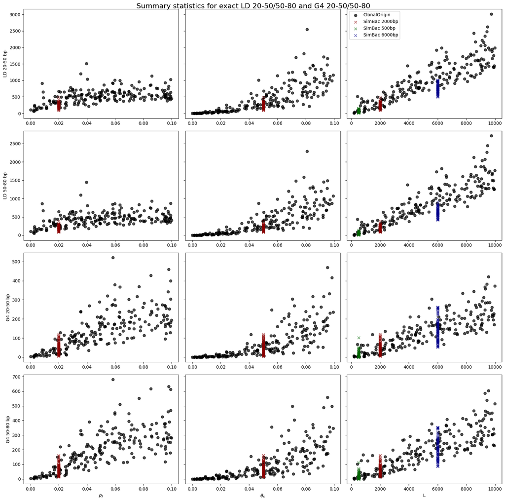

```python
fig, axs = plt.subplots(4, 3, figsize=(16, 16), sharey='row')

x_data = [x_seq[:, 0], x_seq[:, 2], x_seq[:, 3]]
true_x = [0.02, 0.05, 2000]
y_data_matrices = [rho_seq, theta_seq, L_seq]
x_labels = [r'$\rho_s$', r'$\theta_s$', "L"]

for col in range(3):
    x_var = x_data[col]
    fix_x = true_x[col]
    y_mat = y_data_matrices[col]

    axs[0, col].scatter(x_var, y_mat[:, 8], marker='o', color='black', label="ClonalOrigin", alpha=0.7)
    axs[0, col].scatter(np.full(100, fix_x), x_2000_mat[:, 8], marker='x', color='darkred', label = "SimBac 2000bp", alpha=0.5)

    axs[1, col].scatter(x_var, y_mat[:, 9], marker='o', color='black', alpha=0.7)
    axs[1, col].scatter(np.full(100, fix_x), x_2000_mat[:, 9], marker='x', color='darkred', label = "SimBac 2000bp", alpha=0.5)

    axs[2, col].scatter(x_var, y_mat[:, 10], marker='o', color='black', alpha=0.7)
    axs[2, col].scatter(np.full(100, fix_x), x_2000_mat[:, 10], marker='x', color='darkred', label = "SimBac 2000bp", alpha=0.5)

    axs[3, col].scatter(x_var, y_mat[:, 11], marker='o', color='black', alpha=0.7)
    axs[3, col].scatter(np.full(100, fix_x), x_2000_mat[:, 11], marker='x', color='darkred', label = "SimBac 2000bp", alpha=0.5)
    axs[3, col].set_xlabel(x_labels[col])

    if col == 2:
        axs[0, col].scatter(np.full(100, 500), x_500_mat[:, 8], marker='x', color='darkgreen', label = "SimBac 500bp", alpha=0.5)
        axs[0, col].scatter(np.full(100, 6000), x_6000_mat[:, 8], marker='x', color='darkblue', label = "SimBac 6000bp", alpha=0.5)

        axs[1, col].scatter(np.full(100, 500), x_500_mat[:, 9], marker='x', color='darkgreen', label = "SimBac 500bp", alpha=0.5)
        axs[1, col].scatter(np.full(100, 6000), x_6000_mat[:, 9], marker='x', color='darkblue', label = "SimBac 6000bp", alpha=0.5)

        axs[2, col].scatter(np.full(100, 500), x_500_mat[:, 10], marker='x', color='darkgreen', label = "SimBac 500bp", alpha=0.5)
        axs[2, col].scatter(np.full(100, 6000), x_6000_mat[:, 10], marker='x', color='darkblue', label = "SimBac 6000bp", alpha=0.5)

        axs[3, col].scatter(np.full(100, 500), x_500_mat[:, 11], marker='x', color='darkgreen', label = "SimBac 500bp", alpha=0.5)
        axs[3, col].scatter(np.full(100, 6000), x_6000_mat[:, 11], marker='x', color='darkblue', label = "SimBac 6000bp", alpha=0.5)

axs[0, 0].set_ylabel('LD 20-50 bp')
axs[1, 0].set_ylabel('LD 50-80 bp')
axs[2, 0].set_ylabel('G4 20-50 bp')
axs[3, 0].set_ylabel('G4 50-80 bp')

axs[0, 2].legend(loc='best')

plt.suptitle('Summary statistics for exact LD 20-50/50-80 and G4 20-50/50-80', fontsize=16)
plt.tight_layout()
plt.show()
```

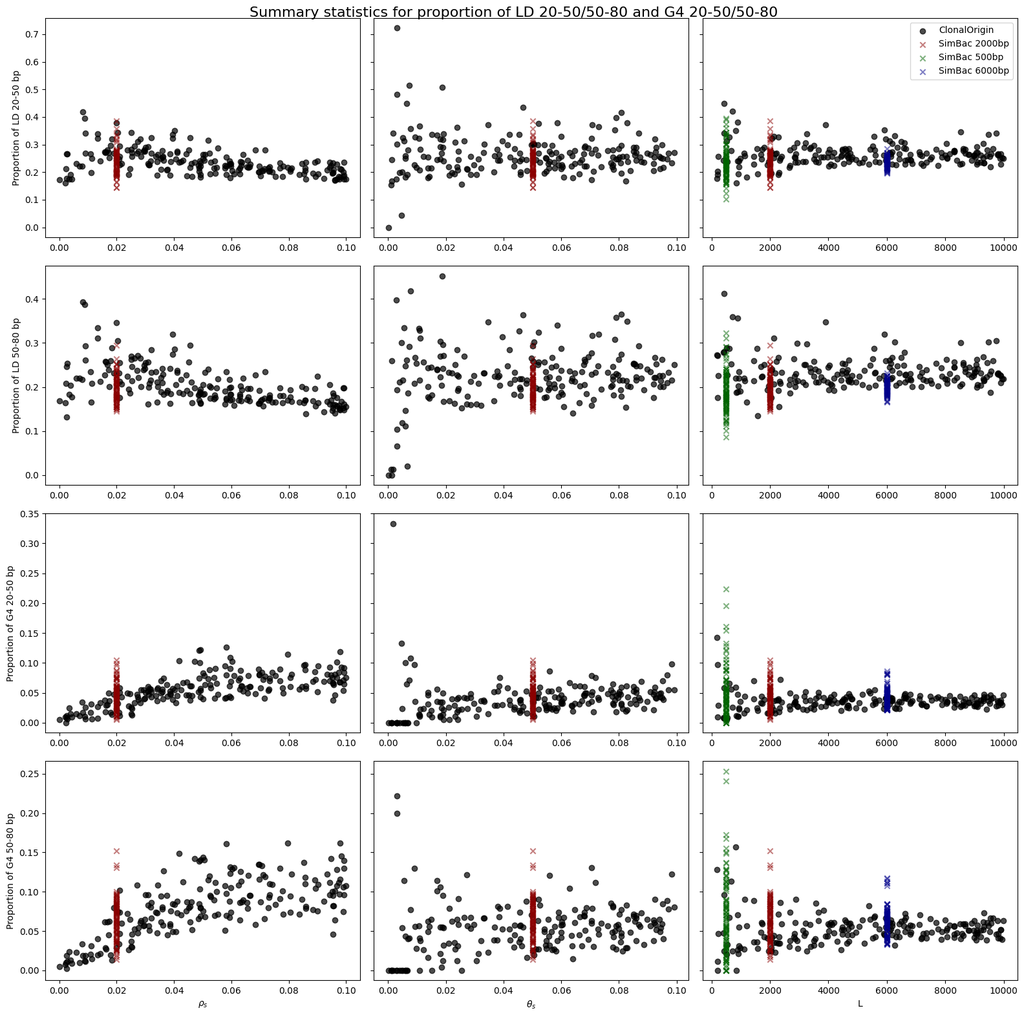

```python
fig, axs = plt.subplots(4, 3, figsize=(16, 16), sharey='row')

x_data = [x_seq[:, 0], x_seq[:, 2], x_seq[:, 3]]
true_x = [0.02, 0.05, 2000]
y_data_matrices = [rho_seq, theta_seq, L_seq]
x_labels = [r'$\rho_s$', r'$\theta_s$', "L"]

for col in range(3):
    x_var = x_data[col]
    fix_x = true_x[col]
    y_mat = y_data_matrices[col]

    axs[0, col].scatter(x_var, y_mat[:, 12], marker='o', color='black', label="ClonalOrigin", alpha=0.7)
    axs[0, col].scatter(np.full(100, fix_x), x_2000_mat[:, 12], marker='x', color='darkred', label = "SimBac 2000bp", alpha=0.5)

    axs[1, col].scatter(x_var, y_mat[:, 13], marker='o', color='black', alpha=0.7)
    axs[1, col].scatter(np.full(100, fix_x), x_2000_mat[:, 13], marker='x', color='darkred', label = "SimBac 2000bp", alpha=0.5)

    axs[2, col].scatter(x_var, y_mat[:, 14], marker='o', color='black', alpha=0.7)
    axs[2, col].scatter(np.full(100, fix_x), x_2000_mat[:, 14], marker='x', color='darkred', label = "SimBac 2000bp", alpha=0.5)

    axs[3, col].scatter(x_var, y_mat[:, 15], marker='o', color='black', alpha=0.7)
    axs[3, col].scatter(np.full(100, fix_x), x_2000_mat[:, 15], marker='x', color='darkred', label = "SimBac 2000bp", alpha=0.5)
    axs[3, col].set_xlabel(x_labels[col])

    if col == 2:
        axs[0, col].scatter(np.full(100, 500), x_500_mat[:, 12], marker='x', color='darkgreen', label = "SimBac 500bp", alpha=0.5)
        axs[0, col].scatter(np.full(100, 6000), x_6000_mat[:, 12], marker='x', color='darkblue', label = "SimBac 6000bp", alpha=0.5)

        axs[1, col].scatter(np.full(100, 500), x_500_mat[:, 13], marker='x', color='darkgreen', label = "SimBac 500bp", alpha=0.5)
        axs[1, col].scatter(np.full(100, 6000), x_6000_mat[:, 13], marker='x', color='darkblue', label = "SimBac 6000bp", alpha=0.5)

        axs[2, col].scatter(np.full(100, 500), x_500_mat[:, 14], marker='x', color='darkgreen', label = "SimBac 500bp", alpha=0.5)
        axs[2, col].scatter(np.full(100, 6000), x_6000_mat[:, 14], marker='x', color='darkblue', label = "SimBac 6000bp", alpha=0.5)

        axs[3, col].scatter(np.full(100, 500), x_500_mat[:, 15], marker='x', color='darkgreen', label = "SimBac 500bp", alpha=0.5)
        axs[3, col].scatter(np.full(100, 6000), x_6000_mat[:, 15], marker='x', color='darkblue', label = "SimBac 6000bp", alpha=0.5)

axs[0, 0].set_ylabel('Proportion of LD 20-50 bp')
axs[1, 0].set_ylabel('Proportion of LD 50-80 bp')
axs[2, 0].set_ylabel('Proportion of G4 20-50 bp')
axs[3, 0].set_ylabel('Proportion of G4 50-80 bp')

axs[0, 2].legend(loc='best')

plt.suptitle('Summary statistics for proportion of LD 20-50/50-80 and G4 20-50/50-80', fontsize=16)
plt.tight_layout()
plt.show()
```

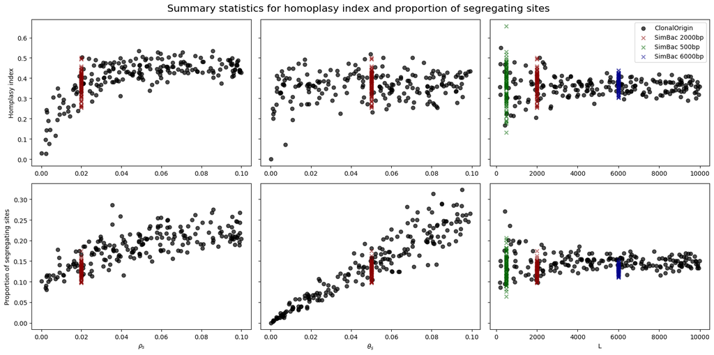

```python
fig, axs = plt.subplots(2, 3, figsize=(16, 8), sharey='row')

x_data = [x_seq[:, 0], x_seq[:, 2], x_seq[:, 3]]
true_x = [0.02, 0.05, 2000]
y_data_matrices = [rho_seq, theta_seq, L_seq]
x_labels = [r'$\rho_s$', r'$\theta_s$', "L"]

for col in range(3):
    x_var = x_data[col]
    fix_x = true_x[col]
    y_mat = y_data_matrices[col]

    axs[0, col].scatter(x_var, y_mat[:, 16], marker='o', color='black', label="ClonalOrigin", alpha=0.7)
    axs[0, col].scatter(np.full(100, fix_x), x_2000_mat[:, 16], marker='x', color='darkred', label = "SimBac 2000bp", alpha=0.5)

    axs[1, col].scatter(x_var, y_mat[:, 17], marker='o', color='black', alpha=0.7)
    axs[1, col].scatter(np.full(100, fix_x), x_2000_mat[:, 17], marker='x', color='darkred', label = "SimBac 2000bp", alpha=0.5)
    axs[1, col].set_xlabel(x_labels[col])

    if col == 2:
        axs[0, col].scatter(np.full(100, 500), x_500_mat[:, 16], marker='x', color='darkgreen', label = "SimBac 500bp", alpha=0.5)
        axs[0, col].scatter(np.full(100, 6000), x_6000_mat[:, 16], marker='x', color='darkblue', label = "SimBac 6000bp", alpha=0.5)

        axs[1, col].scatter(np.full(100, 500), x_500_mat[:, 17], marker='x', color='darkgreen', label = "SimBac 500bp", alpha=0.5)
        axs[1, col].scatter(np.full(100, 6000), x_6000_mat[:, 17], marker='x', color='darkblue', label = "SimBac 6000bp", alpha=0.5)

axs[0, 0].set_ylabel('Homplasy index')
axs[1, 0].set_ylabel('Proportion of segregating sites')

axs[0, 2].legend(loc='best')

plt.suptitle('Summary statistics for homoplasy index and proportion of segregating sites', fontsize=16)
plt.tight_layout()
plt.show()
```

### Summary statistics from ClonalOrigin pair model

In this section, we use the same setting but for the pair model and summary statistics for pair of sites.

```python
x_pair = np.loadtxt('../data/x_pair.csv', delimiter=",")
rho_pair = np.loadtxt('../data/rho_site_pair.csv', delimiter=",")
theta_pair = np.loadtxt('../data/theta_site_pair.csv', delimiter=",")
L_pair = np.loadtxt('../data/L_pair.csv', delimiter=",")
x_pair.shape, rho_pair.shape, theta_pair.shape, L_pair.shape
```

```
((200, 4), (200, 8), (200, 8), (200, 8))
```

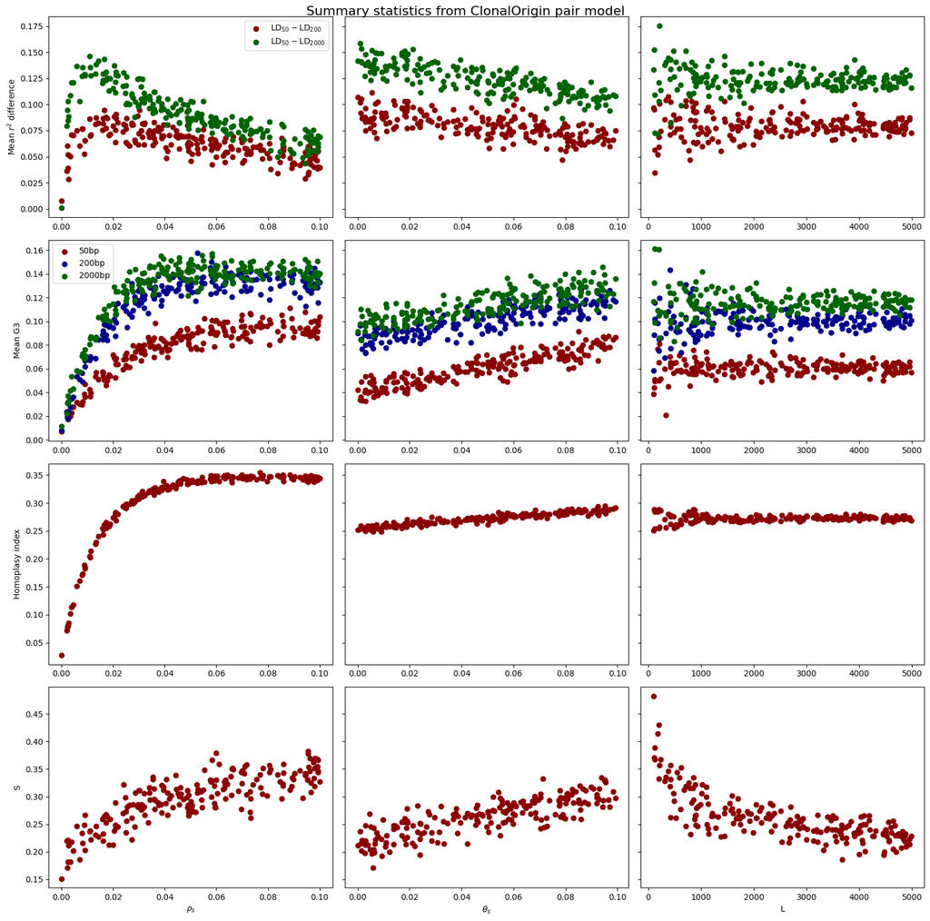

```python
fig, axs = plt.subplots(4, 3, figsize=(16, 16), sharey='row')

x_data = [x_pair[:, 0], x_pair[:, 2], x_pair[:, 3]]
y_data_matrices = [rho_pair, theta_pair, L_pair]
x_labels = [r'$\rho_s$', r'$\theta_s$', "L"]

for col in range(3):
    x_var = x_data[col]
    y_mat = y_data_matrices[col]

    axs[0, col].scatter(x_var, y_mat[:, 0]-y_mat[:, 1], marker='o', color='darkred', label= r"$\text{LD}_{50}-\text{LD}_{200}$")
    axs[0, col].scatter(x_var, y_mat[:, 0]-y_mat[:, 2], marker='o', color='darkgreen', label= r"$\text{LD}_{50}-\text{LD}_{2000}$")

    axs[1, col].scatter(x_var, y_mat[:, 3], marker='o', color='darkred', label = "50bp")
    axs[1, col].scatter(x_var, y_mat[:, 4], marker='o', color='darkblue', label = "200bp")
    axs[1, col].scatter(x_var, y_mat[:, 5], marker='o', color='darkgreen', label = "2000bp")

    axs[2, col].scatter(x_var, y_mat[:, 6], marker='o', color='darkred')

    axs[3, col].scatter(x_var, y_mat[:, 7], marker='o', color='darkred')
    axs[3, col].set_xlabel(x_labels[col])

axs[0, 0].set_ylabel(r'Mean $r^2$ difference')
axs[1, 0].set_ylabel('Mean G3')
axs[2, 0].set_ylabel('Homoplasy index')
axs[3, 0].set_ylabel('S')

axs[0, 0].legend(loc='best')
axs[1, 0].legend(loc='best')

plt.suptitle('Summary statistics from ClonalOrigin pair model', fontsize=16)
plt.tight_layout()
plt.show()
```